# Uygulama - Zaman Serileriyle Regresyon Analizi

Finansal Ekonometri (MPİ-TYL)

Prof. Dr. Hüseyin Taştan

Yıldız Teknik Üniversitesi

# 1 Statik ve Dinamik Modeller

## 1.1 Örnek: Statik Phillips eğrisi

```r
# Install packages
library(wooldridge)
library(dynlm)
library(lmtest)
library(car)
library(forecast)
library(tidyverse)
```

```r
# create a ts object
inf <- ts(phillips$inf, start=1948, frequency = 1)
unem <- ts(phillips$unem, start=1948, frequency = 1)
# tüm veriler
tsphillips <- ts(phillips, start=1948, frequency = 1)
```

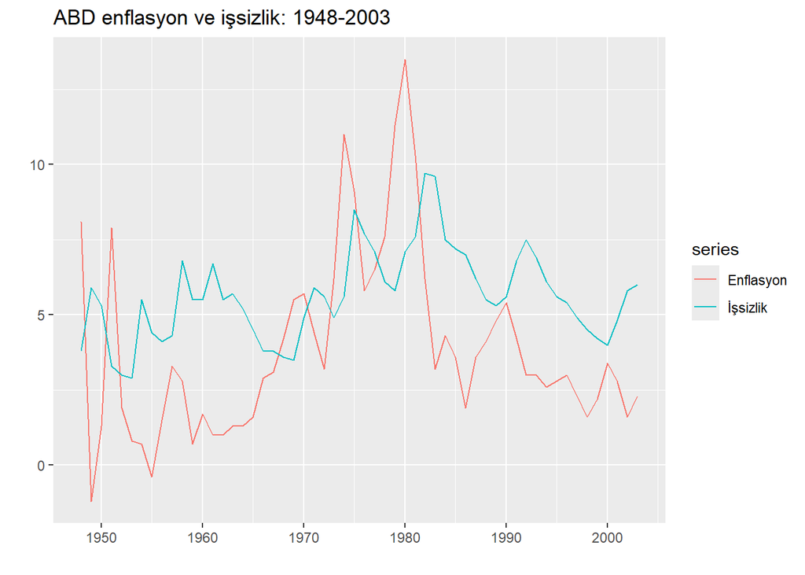

```r
# ts plots
autoplot(inf, series = "Enflasyon") +
  autolayer(unem, series = "İşsizlik") +
  xlab("") + ylab("") +
  ggtitle("ABD enflasyon ve işsizlik: 1948-2003")
```

```r
# statik regresyon
statik <- lm(inf ~ unem, data = phillips)
summary(statik)
```

```
##
## Call:
## lm(formula = inf ~ unem, data = phillips)
##
## Residuals:
##     Min      1Q  Median      3Q     Max
## -5.2176 -1.7812 -0.6659  1.1473  8.8795
##
## Coefficients:
##             Estimate Std. Error t value Pr(>|t|)
## (Intercept)   1.0536     1.5480   0.681   0.4990
## unem          0.5024     0.2656   1.892   0.0639 .
## ---
## Signif. codes:  0 '***' 0.001 '**' 0.01 '*' 0.05 '.' 0.1 ' ' 1
##
## Residual standard error: 2.972 on 54 degrees of freedom
## Multiple R-squared:  0.06215,    Adjusted R-squared:  0.04479
## F-statistic: 3.579 on 1 and 54 DF,  p-value: 0.06389
```

```r
# dynlm paketi ile (yukarıda yüklemiştik)
res1 <- dynlm(inf ~ unem, data  = tsphillips)
summary(res1)
```

```
##
## Time series regression with "ts" data:
## Start = 1948, End = 2003
##
## Call:
## dynlm(formula = inf ~ unem, data = tsphillips)
##
## Residuals:
##     Min      1Q  Median      3Q     Max
## -5.2176 -1.7812 -0.6659  1.1473  8.8795
##
## Coefficients:
##             Estimate Std. Error t value Pr(>|t|)
## (Intercept)   1.0536     1.5480   0.681   0.4990
## unem          0.5024     0.2656   1.892   0.0639 .
## ---
## Signif. codes:  0 '***' 0.001 '**' 0.01 '*' 0.05 '.' 0.1 ' ' 1
##
## Residual standard error: 2.972 on 54 degrees of freedom
## Multiple R-squared:  0.06215,    Adjusted R-squared:  0.04479
## F-statistic: 3.579 on 1 and 54 DF,  p-value: 0.06389
```

Sonuçlar denklem formunda aşağıdaki gibi yazılabilir:
$$\widehat{inf} = 1.05+0.502~unem$$

İşsizlikteki bir puanlık bir artış enflasyonu yaklaşık 0.5 puan arttırmaktadır. Bu sonuç Phillips eğrisi ile uyuşmamaktadır.

Kalıntıları inceleyelim:

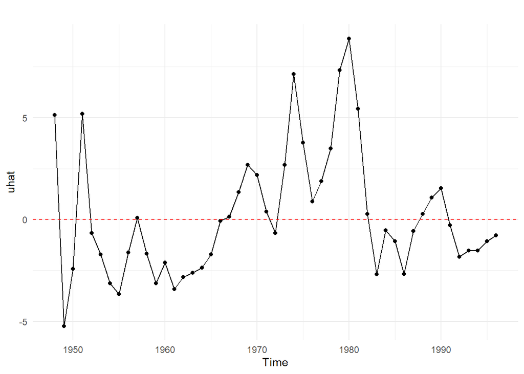

```r
# save the residuals from the static model
uhat <- ts(resid(statik), start=1948, end=1996)
# plot
forecast::autoplot(uhat) + geom_point(aes(y=uhat)) +
  geom_hline(yintercept = 0,linetype="dashed", color = "red") +
  theme_minimal()
```

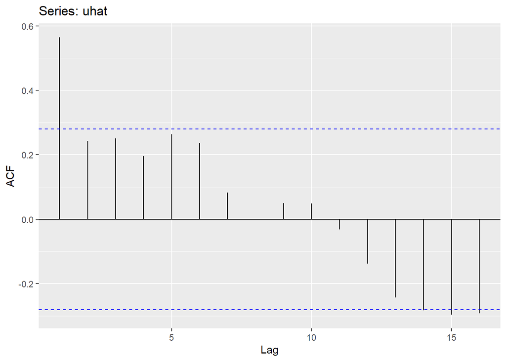

```r
ggAcf(uhat)
```

ACF birinci gecikmede anlamlıdır. Kalıntılarda birinci derece otoregresif ilişki bulunmaktadır. Bunu t testi ile de sınayabiliriz:

```r
# AR(1)
# dynlm paketi ile kalıntıların bir gecikme üzerine regresyonu:
ttestreg <- dynlm(uhat ~ L(uhat)) # L() gecikme işlemi
coeftest(ttestreg)
```

```
##
## t test of coefficients:
##
##              Estimate Std. Error t value Pr(>|t|)
## (Intercept) -0.040596   0.361854 -0.1122   0.9112
## L(uhat)      0.566445   0.116687  4.8544 1.43e-05 ***
## ---
## Signif. codes:  0 '***' 0.001 '**' 0.01 '*' 0.05 '.' 0.1 ' ' 1
```

L(uhat) katsayısı anlamlıdır. Statik modelin kalıntıları otokorelasyonludur.

## 1.2 Örnek: Beklentilerle genişletilmiş Phillips eğirisi

Beklentilerle genişletilmiş Phillips eğrisine göre enflasyon sürprizleri ile işsizlik oranı arasında ters yönlü bir ilişki mevcuttur. Enflasyon sürprizi gerçekleşen enflasyon ile beklenen enflasyon arasındaki farktır. Beklenmeyen (sürpriz) enflasyonu ölçebilmemiz için beklentilerle ilgili bir varsayım yapmamız gerekir. Basitlik amacıyla beklentilerin bir önceki dönemdeki enflasyona göre oluşturulduğunu varsayalım. Böylece sürpriz enflasyon cari değerle bir önceki değer arasındaki fark olacaktır (değişim). Modelimiz:
$$inf_t - inf_{t-1} =\Delta inf_t = \beta_0 +
\beta_1 unem + u$$

```r
res2 <- dynlm( d(inf) ~ unem, data=tsphillips, end=1996)
summary(res2)
```

```
##
## Time series regression with "ts" data:
## Start = 1949, End = 1996
##
## Call:
## dynlm(formula = d(inf) ~ unem, data = tsphillips, end = 1996)
##
## Residuals:
##     Min      1Q  Median      3Q     Max
## -9.1293 -0.7820  0.0611  0.9887  5.3600
##
## Coefficients:
##             Estimate Std. Error t value Pr(>|t|)
## (Intercept)   3.0306     1.3768   2.201   0.0328 *
## unem         -0.5426     0.2302  -2.357   0.0227 *
## ---
## Signif. codes:  0 '***' 0.001 '**' 0.01 '*' 0.05 '.' 0.1 ' ' 1
##
## Residual standard error: 2.451 on 46 degrees of freedom
## Multiple R-squared:  0.1078, Adjusted R-squared:  0.0884
## F-statistic: 5.558 on 1 and 46 DF,  p-value: 0.02271
```

$$\widehat{\Delta inf} =
3.03-0.54~unem$$

```r
uhat2 <- resid(res2)
coeftest( dynlm(uhat2 ~ L(uhat2)) )
```

```
##
## t test of coefficients:
##
##              Estimate Std. Error t value Pr(>|t|)
## (Intercept)  0.194166   0.300384  0.6464   0.5213
## L(uhat2)    -0.035593   0.123891 -0.2873   0.7752
```

L(uhat2) katsayısı istatistik bakımından anlamsızdır. Kalıntılarda otokorelasyon yoktur.

# 2 VAR modelleri

## 2.1 Örnek: BIST100 ve Döviz kurları

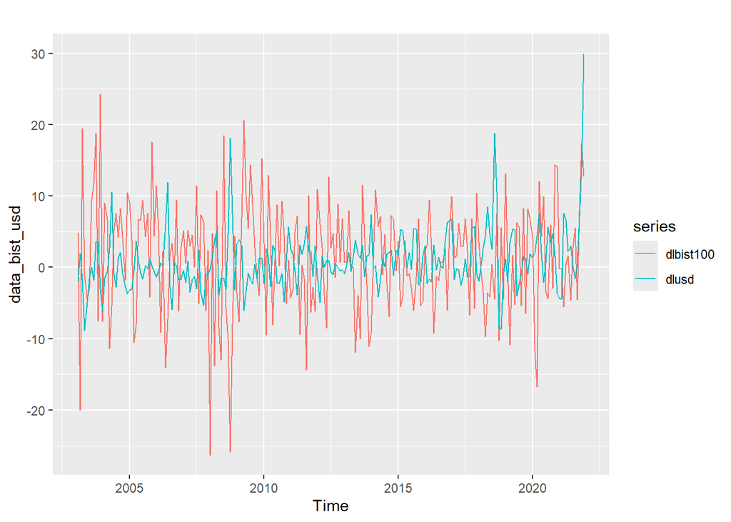

```r
# Aylık veriler
load("../R/Data/bist_usd.rda")
bist100 <- ts(bist_usd$bist100, start = c(2003,1), frequency = 12)
usd <- ts(bist_usd$usd, start = c(2003,1), frequency = 12)
# log birinci farklar
dlbist100 <- 100*diff(log(bist100), 1)
dlusd <- 100*diff(log(usd), 1)
data_bist_usd <- cbind(dlbist100, dlusd)
autoplot(data_bist_usd)
```

```r
# vars paketini aktive edelim
library(vars)
# VAR gecikme uzunluğu (order)
VARselect(data_bist_usd, lag.max = 12)
```

```
## $selection
## AIC(n)  HQ(n)  SC(n) FPE(n)
##      2      2      1      2
##
## $criteria
##                 1          2          3          4          5          6
## AIC(n)   6.714192   6.674453   6.694696   6.715384   6.696493   6.721448
## HQ(n)    6.752198   6.737797   6.783378   6.829403   6.835849   6.886142
## SC(n)    6.808256   6.831227   6.914180   6.997577   7.041395   7.129060
## FPE(n) 824.020543 791.927833 808.145779 825.081633 809.706137 830.263958
##                 7          8          9         10         11         12
## AIC(n)   6.750012   6.768890   6.793784   6.791292   6.824178   6.831227
## HQ(n)    6.940043   6.984259   7.034491   7.057336   7.115560   7.147946
## SC(n)    7.220333   7.301921   7.389525   7.449742   7.545338   7.615096
## FPE(n) 854.456631 870.921108 893.109202 891.175367 921.333430 928.286055
```

Akaike bilgi kriterine (AIC) göre gecikme sayısı p=2 olarak seçildi.

```r
var1 <- VAR(data_bist_usd, type="const", p = 2)
var1
```

```
##
## VAR Estimation Results:
## =======================
##
## Estimated coefficients for equation dlbist100:
## ==============================================
## Call:
## dlbist100 = dlbist100.l1 + dlusd.l1 + dlbist100.l2 + dlusd.l2 + const
##
## dlbist100.l1     dlusd.l1 dlbist100.l2     dlusd.l2        const
##  0.006114682  0.166023613  0.096908754  0.035791774  1.082146089
##
##
## Estimated coefficients for equation dlusd:
## ==========================================
## Call:
## dlusd = dlbist100.l1 + dlusd.l1 + dlbist100.l2 + dlusd.l2 + const
##
## dlbist100.l1     dlusd.l1 dlbist100.l2     dlusd.l2        const
##  -0.06044030   0.56727131   0.05178815  -0.24093899   0.68014746
```

```r
summary(var1)
```

```
##
## VAR Estimation Results:
## =========================
## Endogenous variables: dlbist100, dlusd
## Deterministic variables: const
## Sample size: 225
## Log Likelihood: -1386.689
## Roots of the characteristic polynomial:
## 0.492 0.492 0.3414 0.3049
## Call:
## VAR(y = data_bist_usd, p = 2, type = "const")
##
##
## Estimation results for equation dlbist100:
## ==========================================
## dlbist100 = dlbist100.l1 + dlusd.l1 + dlbist100.l2 + dlusd.l2 + const
##
##              Estimate Std. Error t value Pr(>|t|)
## dlbist100.l1 0.006115   0.071128   0.086   0.9316
## dlusd.l1     0.166024   0.165782   1.001   0.3177
## dlbist100.l2 0.096909   0.075069   1.291   0.1981
## dlusd.l2     0.035792   0.157863   0.227   0.8208
## const        1.082146   0.581892   1.860   0.0643 .
## ---
## Signif. codes:  0 '***' 0.001 '**' 0.01 '*' 0.05 '.' 0.1 ' ' 1
##
##
## Residual standard error: 7.936 on 220 degrees of freedom
## Multiple R-Squared: 0.009925,    Adjusted R-squared: -0.008076
## F-statistic: 0.5514 on 4 and 220 DF,  p-value: 0.6982
##
##
## Estimation results for equation dlusd:
## ======================================
## dlusd = dlbist100.l1 + dlusd.l1 + dlbist100.l2 + dlusd.l2 + const
##
##              Estimate Std. Error t value Pr(>|t|)
## dlbist100.l1 -0.06044    0.03360  -1.799  0.07342 .
## dlusd.l1      0.56727    0.07831   7.244 7.27e-12 ***
## dlbist100.l2  0.05179    0.03546   1.460  0.14560
## dlusd.l2     -0.24094    0.07457  -3.231  0.00142 **
## const         0.68015    0.27488   2.474  0.01410 *
## ---
## Signif. codes:  0 '***' 0.001 '**' 0.01 '*' 0.05 '.' 0.1 ' ' 1
##
##
## Residual standard error: 3.749 on 220 degrees of freedom
## Multiple R-Squared: 0.2573,  Adjusted R-squared: 0.2438
## F-statistic: 19.05 on 4 and 220 DF,  p-value: 1.805e-13
##
##
##
## Covariance matrix of residuals:
##           dlbist100  dlusd
## dlbist100    62.986 -8.756
## dlusd        -8.756 14.055
##
## Correlation matrix of residuals:
##           dlbist100   dlusd
## dlbist100    1.0000 -0.2943
## dlusd       -0.2943  1.0000
```

```r
# Serial korelasyon testi, kalıntılar white noise olmalı
sertest <- serial.test(var1, lags.pt = 12, type = "PT.asymptotic")
sertest
```

```
##
##  Portmanteau Test (asymptotic)
##
## data:  Residuals of VAR object var1
## Chi-squared = 31.78, df = 40, p-value = 0.8199
```

Dizisel korelasyon olmadığını söyleyen boş hipotez kabul edilebilir (p değeri yaklaşık 0.82).

Kalıntıların grafikleri:

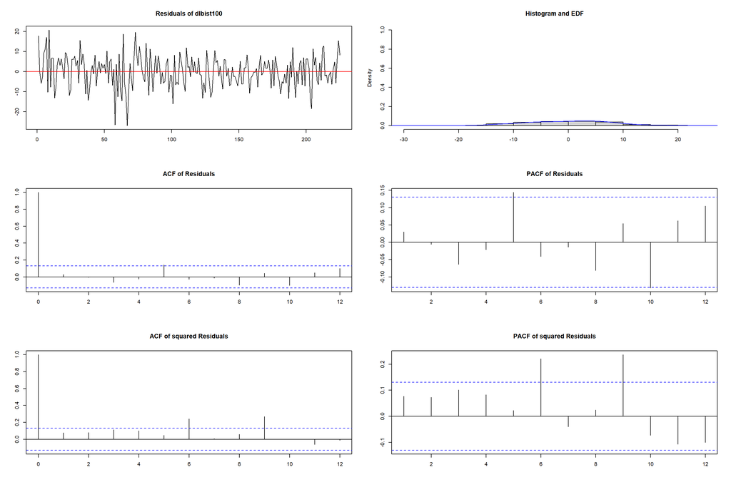

```r
plot(sertest, names = "dlbist100" )
```

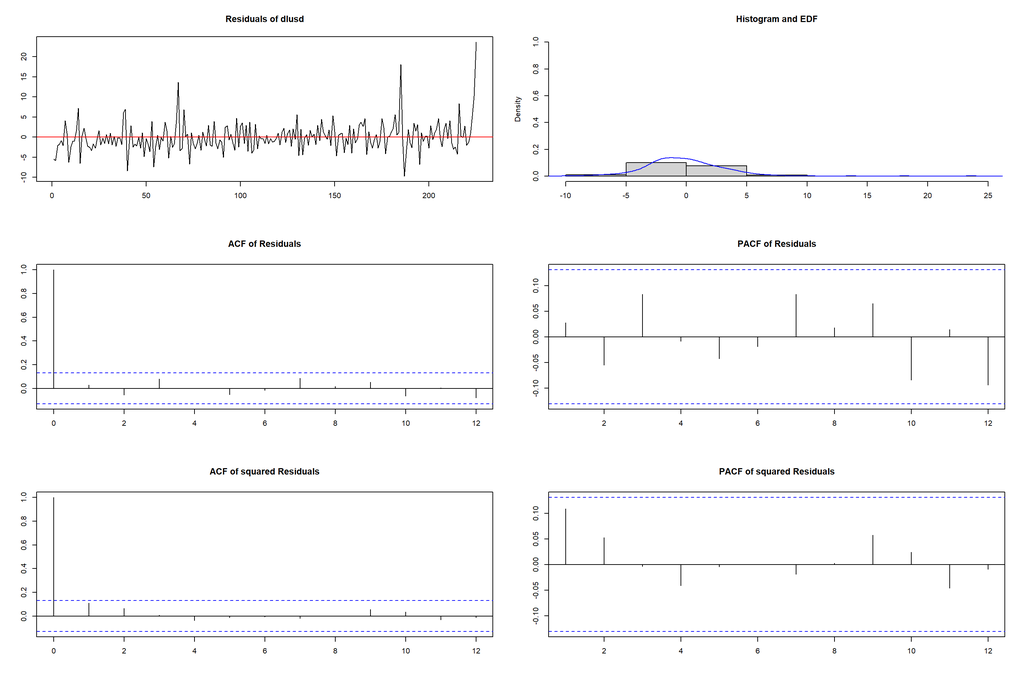

```r
plot(sertest, names = "dlusd" )
```

Granger nedensellik testleri:

```r
# Granger nedensellik testi
gc1 <- causality(var1, cause = "dlbist100")
gc1
```

```
## $Granger
##
##  Granger causality H0: dlbist100 do not Granger-cause dlusd
##
## data:  VAR object var1
## F-Test = 3.1097, df1 = 2, df2 = 440, p-value = 0.04559
##
##
## $Instant
##
##  H0: No instantaneous causality between: dlbist100 and dlusd
##
## data:  VAR object var1
## Chi-squared = 17.932, df = 1, p-value = 2.289e-05
```

dlbist100 dlusd’nin Granger-nedeni değildir diyen boş hipotez %5 düzeyinde reddedilebilir (p-değeri = 0.046). Borsa endeksindeki aylık değişimler döviz kurlarındaki aylık değişimleri öngörmekte başarılıdır.

```r
# Granger nedensellik testi
gc2 <- causality(var1, cause = "dlusd")
gc2
```

```
## $Granger
##
##  Granger causality H0: dlusd do not Granger-cause dlbist100
##
## data:  VAR object var1
## F-Test = 0.6559, df1 = 2, df2 = 440, p-value = 0.5195
##
##
## $Instant
##
##  H0: No instantaneous causality between: dlusd and dlbist100
##
## data:  VAR object var1
## Chi-squared = 17.932, df = 1, p-value = 2.289e-05
```

dlusd dlbist100’ün Granger-nedeni değildir diyen boş hipotez kabul edilebilir (p değeri 0.5195). Döviz kurlarındaki değişim borsa endeksindeki değişimleri öngörmekte başarılı değildir.

VAR modeliyle öngörü:

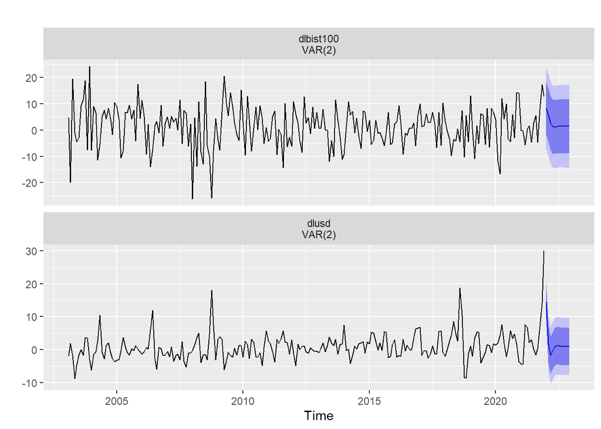

```r
forecast(var1, h=12) |> autoplot()
```

# 3 Uygulama: Konut fiyatları ve faiz ilişkisi

Konut kredi faiz oranı ile konut fiyatları arasında yakın bir ilişki bekleriz. Reel faiz oranlarında bir azalma konut talebini arttırır. Kısa vadede konut arzı sabit olduğundan fiyatlar üzerinden yukarı yönlü bir baskı oluşur. Tersi durumda reel faizlerin artması ise genelde konut fiyatlarında bir azalmaya yol açmasa da enflasyonun üzerinde bir değer artışını baskılayabilir. Öyleyse, diğer herşey aynıyken konut fiyatı ile reel faizler arasında negatif yönlü bir ilişki bekleyebiliriz. Ayrıca bu iki değişken birbirini öngörmede başarılı olabilir. Bu örnekte konut fiyatları ile faiz arasında bir VAR modeli tahmin edeceğiz ve öngörü ilişkisini Granger-nedensellik testlerini kullanarak inceleyeceğiz.

## 3.1 Verilerin okutulması ve grafiksel analiz

```r
library(tidyverse)
library(forecast)
```

```r
# verileri yükle:
load("../R/Data/faiz_kfe_veri.RData")
head(faiz_kfe_veri)
```

```
##            kfe_tr    faiz  tufe_tr     enf_aa    enf_yy
## Jan 2010 100.0000 12.1300 100.0000  1.8489263  8.185208
## Feb 2010 100.4405 11.9750 101.4477  1.4476935 10.127845
## Mar 2010 101.3216 11.7525 102.0394  0.5832720  9.560819
## Apr 2010 101.7621 11.5000 102.6484  0.5967796 10.194265
## May 2010 102.4229 11.5050 102.2807 -0.3581822  9.099822
## Jun 2010 102.6432 11.2950 101.7062 -0.5616715  8.367509
```

`kfe_tr`: Türkiye için konut fiyat endeksi (Kaynak: TCMB);

`faiz`: ortalama konut kredisi faiz oranı (Kaynak: TCMB),

`tufe_tr`: Tüketici Fiyat Endeksi (Kaynak: TÜİK);

`enf_aa`: aydan aya TUFE büyüme oranı,

`enfa_yy`: yıldan yıla TUFE büyüme oranı.

`kfe_tr` ve `tufe_tr` başlangıç değeri 100 olacak şekilde orantılandırıldı.

Verilerin zaman seriği grafiğini çizelim:

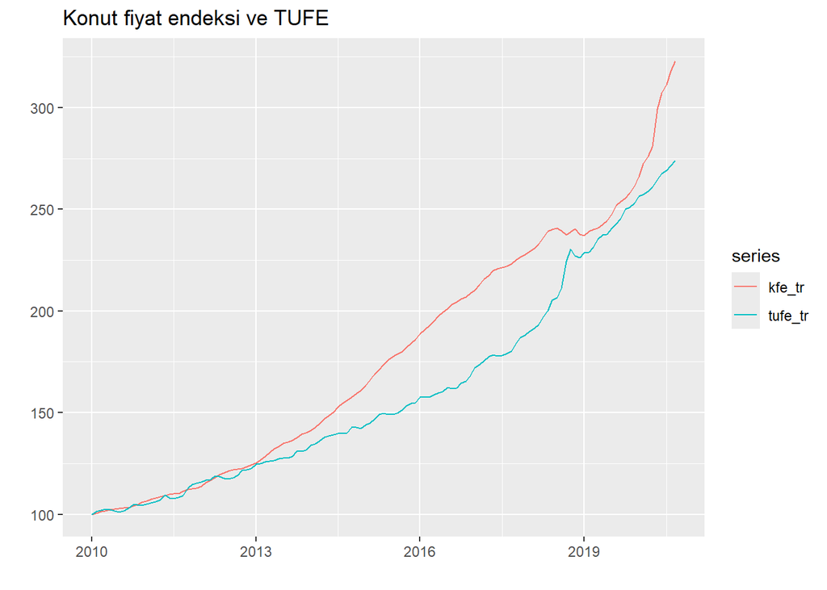

```r
autoplot(faiz_kfe_veri[, c("kfe_tr", "tufe_tr")]) +
  xlab("") + ylab("") +
  ggtitle("Konut fiyat endeksi ve TUFE")
```

Konut fiyat endeksi (KFE) ve TUFE 2010-2013 arasında yaklaşık olarak aynı oranlarda artış gösterirken daha sonraki dönemde konut fiyatlarının reel olarak arttığını görüyoruz. Enflasyon etkisini arındırmak için konut fiyat endeksini TUFE’ye bölebiliriz:

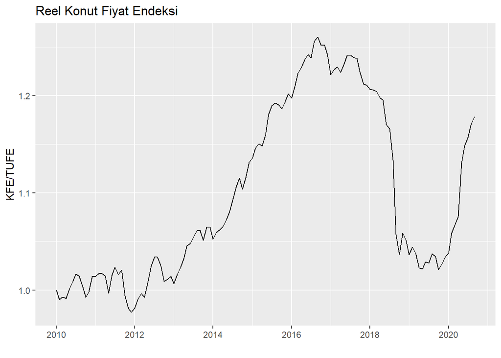

```r
kfe_tr <- faiz_kfe_veri[, "kfe_tr"]
tufe_tr <- faiz_kfe_veri[, "tufe_tr"]
# reel konut fiyat endeksi:
rkfe_tr <- kfe_tr/tufe_tr
autoplot(rkfe_tr) +
  xlab("") + ylab("KFE/TUFE") +
  ggtitle("Reel Konut Fiyat Endeksi")
```

Konut kredisi faiz oranlarına bakalım:

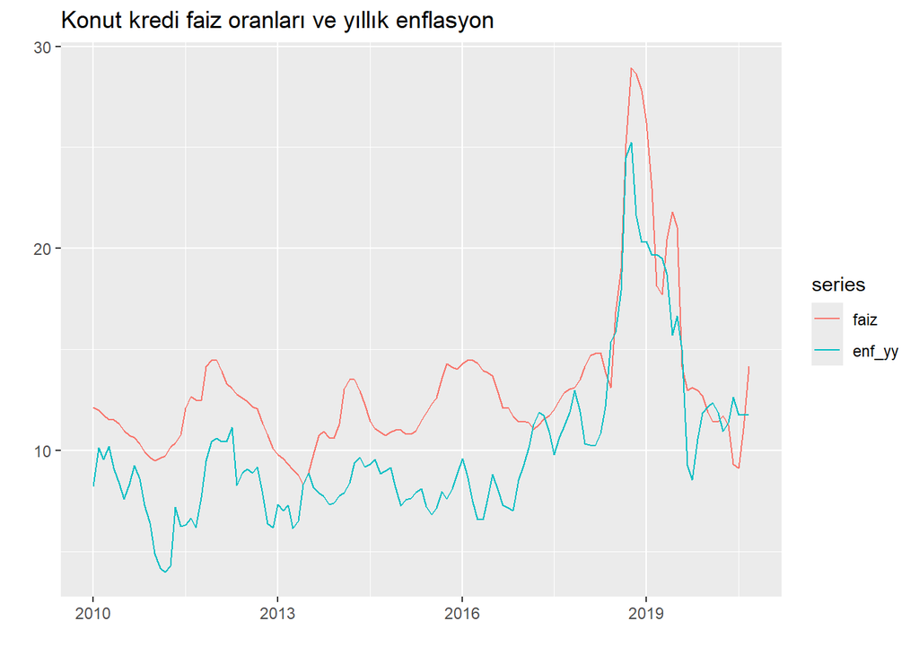

```r
autoplot(faiz_kfe_veri[, c("faiz", "enf_yy")]) +
  xlab("") + ylab("") +
  ggtitle("Konut kredi faiz oranları ve yıllık enflasyon")
```

Reel faiz oranları

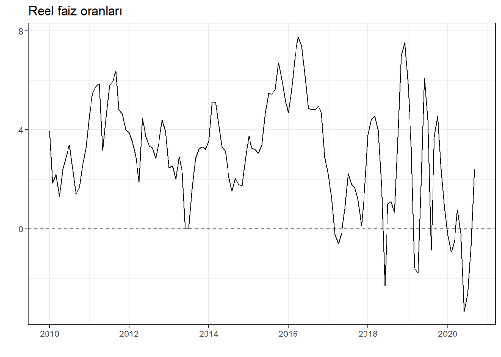

```r
faiz <- faiz_kfe_veri[, "faiz"]
enf_yy <- faiz_kfe_veri[, "enf_yy"]
# ex post reel faiz
rfaiz <- faiz-enf_yy
autoplot(rfaiz) +
  geom_hline(yintercept=0, linetype=2) +
  theme_bw() +
  xlab("") + ylab("") +
  ggtitle("Reel faiz oranları")
```

```r
# rfaiz2 = ((1+faiz/100)/(1+enf_yy/100)) - 1
# autoplot(cbind(faiz,100*rfaiz2))
```

## 3.2 Konut kredi faizleri ve fiyatlar durağan mı?

Konut fiyatlarının faiz oranı üzerine regresyonunu kuralım. Regresyon modeli için `R`’ın `lm()` fonksiyonunu kullanabiliriz. Zaman serisi için daha fazla tercih sunan `forecast::tslm()` fonksiyonunu da kullanabiliriz:

```r
# yeni bir ts veri seti oluştur
tsdata <- cbind(rkfe_tr, faiz, enf_yy, rfaiz)
# log-level modeli tahmin et
fit1 <- tslm(log(rkfe_tr) ~ rfaiz, data=tsdata)
summary(fit1)
```

```
##
## Call:
## tslm(formula = log(rkfe_tr) ~ rfaiz, data = tsdata)
##
## Residuals:
##      Min       1Q   Median       3Q      Max
## -0.11284 -0.07020 -0.03004  0.08403  0.14135
##
## Coefficients:
##              Estimate Std. Error t value Pr(>|t|)
## (Intercept) 0.0888781  0.0119781   7.420 1.48e-11 ***
## rfaiz       0.0002705  0.0031971   0.085    0.933
## ---
## Signif. codes:  0 '***' 0.001 '**' 0.01 '*' 0.05 '.' 0.1 ' ' 1
##
## Residual standard error: 0.08072 on 127 degrees of freedom
## Multiple R-squared:  5.638e-05,  Adjusted R-squared:  -0.007817
## F-statistic: 0.00716 on 1 and 127 DF,  p-value: 0.9327
```

Bu sonuçlara göre reel faiz oranları (rfaiz) istatistik bakımından anlamsızdır. Ancak hatırlarsak zaman serileriyle regresyon sonuçlarının durağan olmama, güçlü otokorelasyon gibi nedenlerden dolayı yanlış sonuçlar verebileceğini söylemiştik. Bunu kalıntıların grafiğinden de görebiliriz:

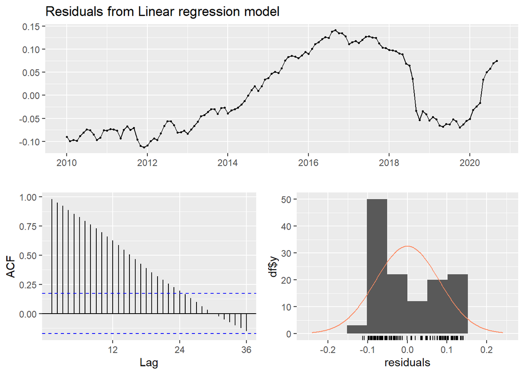

```
##
##  Breusch-Godfrey test for serial correlation of order up to 24
##
## data:  Residuals from Linear regression model
## LM test = 125.77, df = 24, p-value = 8.983e-16
```

```r
uhat <- resid(fit1)
checkresiduals(fit1)
```

Kalıntıların ACF değerleri çok yüksek ve güçlü bağımlılığa işaret ediyor. Değişkenler durağan olmayabilir.

Birim kök testlerini hesaplayalım:

```r
# KPSS testi
# H0: seri durağan
# H1: seri durağan değil
kpss1 <- ur.kpss(log(rkfe_tr))
summary(kpss1)
```

```
##
## #######################
## # KPSS Unit Root Test #
## #######################
##
## Test is of type: mu with 4 lags.
##
## Value of test-statistic is: 1.1768
##
## Critical value for a significance level of:
##                 10pct  5pct 2.5pct  1pct
## critical values 0.347 0.463  0.574 0.739
```

Bu sonuca göre H0 red edilebilir (test istatistiği kritik değerlerden büyüktür). Birinci farkı alıp tekrar test edelim:

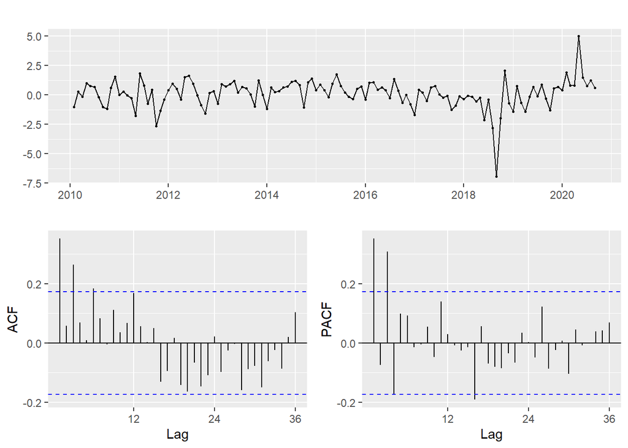

```r
dlrkfe <- 100*diff(log(rkfe_tr))
ggtsdisplay(dlrkfe)
```

```r
# KPSS test
# birinci farkı alınmış seri
summary(ur.kpss(dlrkfe))
```

```
##
## #######################
## # KPSS Unit Root Test #
## #######################
##
## Test is of type: mu with 4 lags.
##
## Value of test-statistic is: 0.1352
##
## Critical value for a significance level of:
##                 10pct  5pct 2.5pct  1pct
## critical values 0.347 0.463  0.574 0.739
```

Bu sonuca göre H0 kabul edilir (0.1352<0.46), yani dlrkfe durağandır. Böylece RKFE’nin I(1) olduğunu söyleyebiliriz.

Benzer şekilde reel faizlerin durağan olup olmadığını araştıralım.

```r
# KPSS test
# reel faiz
summary(ur.kpss(rfaiz))
```

```
##
## #######################
## # KPSS Unit Root Test #
## #######################
##
## Test is of type: mu with 4 lags.
##
## Value of test-statistic is: 0.4671
##
## Critical value for a significance level of:
##                 10pct  5pct 2.5pct  1pct
## critical values 0.347 0.463  0.574 0.739
```

Bu sonuçlara göre rfaiz durağandır (H0 kabul edilebilir, test istatistiği %2.5 kritik değerinden küçüktür).

Alternatif olarak Augmented Dickey-Fuller (ADF) birim kök testleri de yapılabilir. Bu testin boş hipotezi serinin durağan olmadığını söyler.

```r
# ADF Birim kök testi
# H0: seri durağan değil
# H1: seri durağan (ya da trend-durağan)
library(urca)
# log reel KFE
adf1 <- ur.df(log(rkfe_tr) , type = c("drift"), lags=6, selectlags="AIC")
summary(adf1)
```

```
##
## ###############################################
## # Augmented Dickey-Fuller Test Unit Root Test #
## ###############################################
##
## Test regression drift
##
##
## Call:
## lm(formula = z.diff ~ z.lag.1 + 1 + z.diff.lag)
##
## Residuals:
##       Min        1Q    Median        3Q       Max
## -0.047092 -0.004766  0.000853  0.005605  0.039086
##
## Coefficients:
##              Estimate Std. Error t value Pr(>|t|)
## (Intercept)  0.002246   0.001514   1.484  0.14052
## z.lag.1     -0.017869   0.012532  -1.426  0.15660
## z.diff.lag1  0.492413   0.091674   5.371 4.13e-07 ***
## z.diff.lag2 -0.286319   0.100101  -2.860  0.00503 **
## z.diff.lag3  0.436467   0.095899   4.551 1.33e-05 ***
## z.diff.lag4 -0.229065   0.100099  -2.288  0.02394 *
## z.diff.lag5  0.144619   0.098684   1.465  0.14552
## ---
## Signif. codes:  0 '***' 0.001 '**' 0.01 '*' 0.05 '.' 0.1 ' ' 1
##
## Residual standard error: 0.01078 on 115 degrees of freedom
## Multiple R-squared:  0.2734, Adjusted R-squared:  0.2355
## F-statistic: 7.212 on 6 and 115 DF,  p-value: 1.506e-06
##
##
## Value of test-statistic is: -1.4259 1.2074
##
## Critical values for test statistics:
##       1pct  5pct 10pct
## tau2 -3.46 -2.88 -2.57
## phi1  6.52  4.63  3.81
```

ADF test istatistiği $-1.43$ ve %5 düzeyindeki kritik değerden $-2.88$ büyük. Konut fiyat endeksinin durağan olmadığını söyleyen boş hipotez reddedilemez (sol kuyruk testi). Seri durağan değildir.

Acaba trend eklediğimizde de aynı sonuç mu çıkıyor? Bu durumda alternatif hipotez serinin trend-durağan olduğunu söyler.

```r
# sabit+trend
adf2 <- ur.df(log(rkfe_tr) , type = c("trend"), lags=6, selectlags="AIC")
summary(adf2)
```

```
##
## ###############################################
## # Augmented Dickey-Fuller Test Unit Root Test #
## ###############################################
##
## Test regression trend
##
##
## Call:
## lm(formula = z.diff ~ z.lag.1 + 1 + tt + z.diff.lag)
##
## Residuals:
##       Min        1Q    Median        3Q       Max
## -0.049342 -0.004338  0.001101  0.005614  0.036378
##
## Coefficients:
##               Estimate Std. Error t value Pr(>|t|)
## (Intercept)  3.432e-04  2.148e-03   0.160 0.873371
## z.lag.1     -3.015e-02  1.487e-02  -2.027 0.044982 *
## tt           4.418e-05  3.321e-05   1.330 0.186052
## z.diff.lag1  4.793e-01  9.187e-02   5.217 8.34e-07 ***
## z.diff.lag2 -2.518e-01  1.024e-01  -2.459 0.015456 *
## z.diff.lag3  3.928e-01  1.028e-01   3.820 0.000219 ***
## z.diff.lag4 -1.817e-01  1.041e-01  -1.745 0.083632 .
## z.diff.lag5  1.035e-01  1.094e-01   0.945 0.346464
## z.diff.lag6  1.421e-01  1.004e-01   1.416 0.159436
## ---
## Signif. codes:  0 '***' 0.001 '**' 0.01 '*' 0.05 '.' 0.1 ' ' 1
##
## Residual standard error: 0.01072 on 113 degrees of freedom
## Multiple R-squared:  0.2936, Adjusted R-squared:  0.2436
## F-statistic: 5.871 on 8 and 113 DF,  p-value: 2.839e-06
##
##
## Value of test-statistic is: -2.0273 1.5184 2.0956
##
## Critical values for test statistics:
##       1pct  5pct 10pct
## tau3 -3.99 -3.43 -3.13
## phi2  6.22  4.75  4.07
## phi3  8.43  6.49  5.47
```

$ADF=-2.027$ değeri dağılımın kabul bölgesinde, boş hipotez reddedilemez. Sabit ve trend modelinde de seri durağan değildir.

Serinin birinci farkını aldığımızda durağanlaşıyor mu?

```r
# Her iki durumda da durağan değil
# birinci farkı alınca durağanlaşıyor mu
adf3 <- ur.df(diff(log(rkfe_tr)) , type = c("drift"), lags=6, selectlags="AIC")
summary(adf3)
```

```
##
## ###############################################
## # Augmented Dickey-Fuller Test Unit Root Test #
## ###############################################
##
## Test regression drift
##
##
## Call:
## lm(formula = z.diff ~ z.lag.1 + 1 + z.diff.lag)
##
## Residuals:
##       Min        1Q    Median        3Q       Max
## -0.049609 -0.004760 -0.000145  0.006132  0.040625
##
## Coefficients:
##               Estimate Std. Error t value Pr(>|t|)
## (Intercept)  0.0007098  0.0009991   0.710   0.4789
## z.lag.1     -0.5554360  0.1230455  -4.514 1.54e-05 ***
## z.diff.lag1  0.0270222  0.1251841   0.216   0.8295
## z.diff.lag2 -0.2170863  0.1019665  -2.129   0.0354 *
## z.diff.lag3  0.1866669  0.0915777   2.038   0.0438 *
## ---
## Signif. codes:  0 '***' 0.001 '**' 0.01 '*' 0.05 '.' 0.1 ' ' 1
##
## Residual standard error: 0.01088 on 116 degrees of freedom
## Multiple R-squared:  0.4189, Adjusted R-squared:  0.3989
## F-statistic: 20.91 on 4 and 116 DF,  p-value: 5.358e-13
##
##
## Value of test-statistic is: -4.5141 10.1918
##
## Critical values for test statistics:
##       1pct  5pct 10pct
## tau2 -3.46 -2.88 -2.57
## phi1  6.52  4.63  3.81
```

Bu durumda $ADF=-4.51$ ve bu %1 düzeyindeki kritik değerden küçüktür. Öyleyse serinin durağan olmadığını söyleyen boş hipotez reddedilir. Konut fiyat endeksinin büyüme oranı durağandır (logaritmik birinci fark büyüme oranını verir). Farkın grafiği ve korelogramı aşağıdaki gibidir:

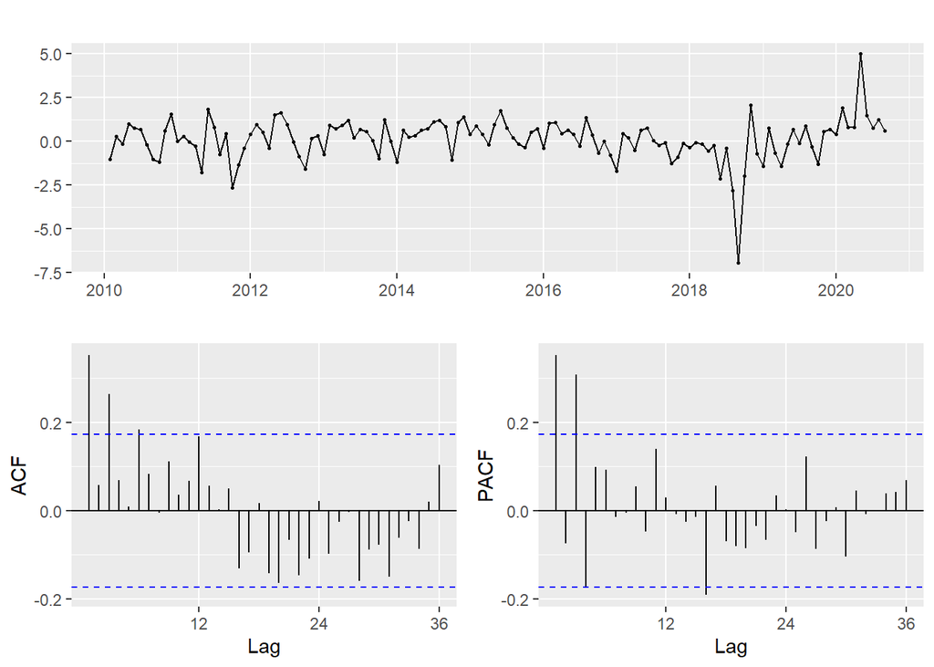

```r
dlrkfe <- 100*diff(log(rkfe_tr))
ggtsdisplay(dlrkfe)
```

Reel faizler durağan mı?

```r
adf4 <- ur.df(rfaiz, type = c("drift"), lags=6, selectlags="AIC")
summary(adf4)
```

```
##
## ###############################################
## # Augmented Dickey-Fuller Test Unit Root Test #
## ###############################################
##
## Test regression drift
##
##
## Call:
## lm(formula = z.diff ~ z.lag.1 + 1 + z.diff.lag)
##
## Residuals:
##     Min      1Q  Median      3Q     Max
## -4.3159 -0.7993  0.0406  0.7449  5.0750
##
## Coefficients:
##             Estimate Std. Error t value Pr(>|t|)
## (Intercept)  0.70176    0.23300   3.012 0.003178 **
## z.lag.1     -0.23270    0.06424  -3.622 0.000432 ***
## z.diff.lag1  0.33992    0.08631   3.938 0.000139 ***
## z.diff.lag2 -0.23418    0.09255  -2.530 0.012709 *
## ---
## Signif. codes:  0 '***' 0.001 '**' 0.01 '*' 0.05 '.' 0.1 ' ' 1
##
## Residual standard error: 1.348 on 118 degrees of freedom
## Multiple R-squared:  0.2531, Adjusted R-squared:  0.2341
## F-statistic: 13.33 on 3 and 118 DF,  p-value: 1.493e-07
##
##
## Value of test-statistic is: -3.6221 6.5694
##
## Critical values for test statistics:
##       1pct  5pct 10pct
## tau2 -3.46 -2.88 -2.57
## phi1  6.52  4.63  3.81
```

ADF test istatistiği $-3.62$ ve bu değer %1 kritik değerden küçük (mutlak olarak büyük). Bu nedenle boş hipotez reddedilir. Faiz serisi durağandır.

Özetlersek RKFE serisi seviyede durağan değil ancak birinci farkı durağan. Reel faizler ise seviyede durağan. Bu durumda takip edilebilecek bir yol KFE serisinin birinci farkı ile faizler arasında bir dinamik model kurmaktır. Bu amaçla VAR modelleri kullanılabilir.

## 3.3 VAR Modeli ve Granger-nedensellik analizi

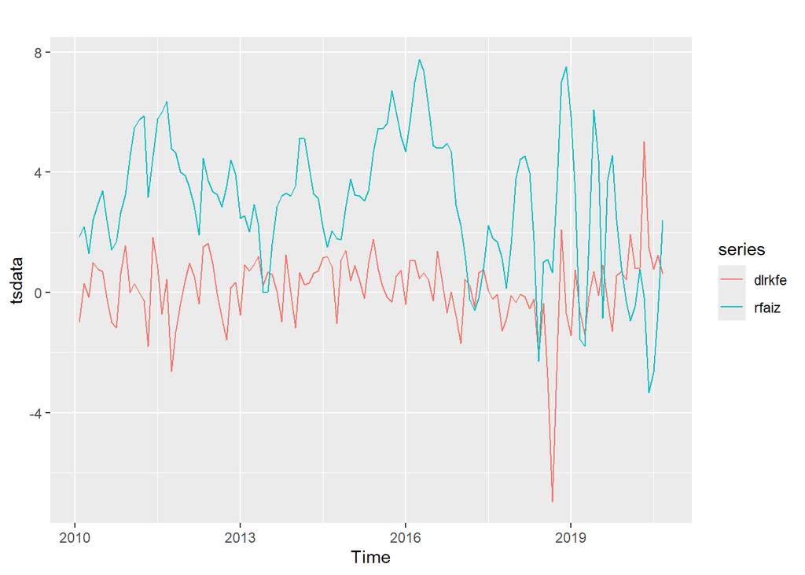

```r
# birinci farkı alınca bir gözlem kaybı nedeniyle dönem tanımı:
dlrkfe <- window(dlrkfe, start=c(2010,2), end=c(2020,9))
rfaiz <- window(rfaiz, start=c(2010,2), end=c(2020,9))
# veri seti oluştur
tsdata <- cbind(dlrkfe, rfaiz)
autoplot(tsdata)
```

```r
library(vars)
var1 <- VAR(tsdata, type="const", lag.max = 6, ic="AIC")
summary(var1)
```

```
##
## VAR Estimation Results:
## =========================
## Endogenous variables: dlrkfe, rfaiz
## Deterministic variables: const
## Sample size: 125
## Log Likelihood: -390.46
## Roots of the characteristic polynomial:
## 0.8192 0.6565 0.6565 0.6401 0.5694 0.5694
## Call:
## VAR(y = tsdata, type = "const", lag.max = 6, ic = "AIC")
##
##
## Estimation results for equation dlrkfe:
## =======================================
## dlrkfe = dlrkfe.l1 + rfaiz.l1 + dlrkfe.l2 + rfaiz.l2 + dlrkfe.l3 + rfaiz.l3 + const
##
##           Estimate Std. Error t value Pr(>|t|)
## dlrkfe.l1  0.41470    0.08948   4.634  9.3e-06 ***
## rfaiz.l1  -0.03817    0.07745  -0.493 0.623034
## dlrkfe.l2 -0.21580    0.09923  -2.175 0.031644 *
## rfaiz.l2   0.05197    0.10975   0.474 0.636692
## dlrkfe.l3  0.32031    0.09041   3.543 0.000568 ***
## rfaiz.l3  -0.04935    0.07911  -0.624 0.533931
## const      0.18449    0.19067   0.968 0.335229
## ---
## Signif. codes:  0 '***' 0.001 '**' 0.01 '*' 0.05 '.' 0.1 ' ' 1
##
##
## Residual standard error: 1.106 on 118 degrees of freedom
## Multiple R-Squared: 0.2213,  Adjusted R-squared: 0.1817
## F-statistic: 5.589 on 6 and 118 DF,  p-value: 3.931e-05
##
##
## Estimation results for equation rfaiz:
## ======================================
## rfaiz = dlrkfe.l1 + rfaiz.l1 + dlrkfe.l2 + rfaiz.l2 + dlrkfe.l3 + rfaiz.l3 + const
##
##           Estimate Std. Error t value Pr(>|t|)
## dlrkfe.l1 -0.27109    0.10621  -2.552 0.011977 *
```

[output cut: 10 more lines]

```
## Residual standard error: 1.313 on 118 degrees of freedom
## Multiple R-Squared: 0.6781,  Adjusted R-squared: 0.6617
## F-statistic: 41.43 on 6 and 118 DF,  p-value: < 2.2e-16
##
##
##
## Covariance matrix of residuals:
##        dlrkfe rfaiz
## dlrkfe  1.223 0.346
## rfaiz   0.346 1.723
##
## Correlation matrix of residuals:
##        dlrkfe  rfaiz
## dlrkfe 1.0000 0.2383
## rfaiz  0.2383 1.0000
```

Gecikme uzunluğu AIC kriterine göre 3 olarak belirlendi. Ayrıca bkz:

```r
VARselect(tsdata, lag.max = 6, type = "const")
```

```
## $selection
## AIC(n)  HQ(n)  SC(n) FPE(n)
##      3      3      3      3
##
## $criteria
##               1         2         3         4         5         6
## AIC(n) 1.031657 0.9437188 0.8324023 0.8376952 0.8687462 0.8679725
## HQ(n)  1.087669 1.0370718 0.9630965 1.0057306 1.0741228 1.1106903
## SC(n)  1.169560 1.1735566 1.1541752 1.2514032 1.3743893 1.4655508
## FPE(n) 2.805767 2.5697552 2.2994149 2.3122759 2.3862624 2.3859487
```

Reel faizler ev fiyatlarındaki reel artışların Granger-nedeni midir?

```r
# Granger causality
# H0: reel faizler ev fiyatlarının Granger-nedeni değildir
causality(var1, cause = "rfaiz")
```

```
## $Granger
##
##  Granger causality H0: rfaiz do not Granger-cause dlrkfe
##
## data:  VAR object var1
## F-Test = 0.20459, df1 = 3, df2 = 236, p-value = 0.8932
##
##
## $Instant
##
##  H0: No instantaneous causality between: rfaiz and dlrkfe
##
## data:  VAR object var1
## Chi-squared = 6.7195, df = 1, p-value = 0.009536
```

Test istatistiği F-Test = 0.20 ve p-değeri 0.89 olarak hesaplandı. Buna göre boş hipotez reddedilemez. Reel faizler konut fiyat artışlarının Granger-nedeni değildir. Bir başka ifadeyle reel faizler reel konut fiyat artışlarını öngörmede başarılı değildir. Konut fiyat artışlarını etkileyen ve öngörmede daha başarılı olacak faktörlerin modele eklenmesi gerekir.

Ev fiyatlarındaki reel artışlar konut kredi faizinin Granger-nedeni midir?

```r
# H0: ev fiyatları reel faizlerin Granger-nedeni değildir
causality(var1, cause = "dlrkfe")
```

```
## $Granger
##
##  Granger causality H0: dlrkfe do not Granger-cause rfaiz
##
## data:  VAR object var1
## F-Test = 2.4419, df1 = 3, df2 = 236, p-value = 0.06493
##
##
## $Instant
##
##  H0: No instantaneous causality between: dlrkfe and rfaiz
##
## data:  VAR object var1
## Chi-squared = 6.7195, df = 1, p-value = 0.009536
```

Test istatistiği F-Test = 2.44 ve p-değeri=0.06. Zayıf olsa da boş hipotez aleyhinde kanıt mevcut diyebiliriz. Öyleyse, en azından bu basit modelde, ev fiyatlarındaki reel artışların reel faizleri öngörmede başarılı olduğu söylenebilir.